# 11주차

Hosub Park

2016년 6월 5일

## <11주차>

### 1. Using the teengamb data, model gamble as the response and the other variables as predictors. Take care to investigate the possibility of interactions between sex and the other predictors. Interpret your final model.

```r
library(faraway)
data(teengamb)

teengamb$sex <- factor(teengamb$sex, label=c("male","female"))
```

#### 모델 만들기

```r
mdl_int <- lm(gamble~.*sex, data=teengamb)
summary(mdl_int)
```

```
##
## Call:
## lm(formula = gamble ~ . * sex, data = teengamb)
##
## Residuals:
##     Min      1Q  Median      3Q     Max
## -56.654  -7.589  -1.016   3.323  83.903
##
## Coefficients:
##                  Estimate Std. Error t value Pr(>|t|)
## (Intercept)       27.6354    17.6218   1.568   0.1249
## sexfemale        -33.0132    35.0530  -0.942   0.3521
## status            -0.1456     0.3316  -0.439   0.6631
## income             6.0291     1.0538   5.721 1.26e-06 ***
## verbal            -2.9748     2.4265  -1.226   0.2276
## sexfemale:status   0.3529     0.5492   0.643   0.5243
## sexfemale:income  -5.3478     2.4244  -2.206   0.0334 *
## sexfemale:verbal   2.8355     4.5973   0.617   0.5410
## ---
## Signif. codes:  0 '***' 0.001 '**' 0.01 '*' 0.05 '.' 0.1 ' ' 1
##
## Residual standard error: 20.98 on 39 degrees of freedom
## Multiple R-squared:  0.6243, Adjusted R-squared:  0.5569
## F-statistic:  9.26 on 7 and 39 DF,  p-value: 1.06e-06
```

```r
anova(mdl_int)
```

```
## Analysis of Variance Table
##
## Response: gamble
##            Df  Sum Sq Mean Sq F value    Pr(>F)
## sex         1  7598.4  7598.4 17.2655 0.0001717 ***
## status      1  3613.0  3613.0  8.2096 0.0066802 **
## income      1 11898.6 11898.6 27.0367 6.657e-06 ***
## verbal      1   955.7   955.7  2.1717 0.1485994
## sex:status  1  2103.3  2103.3  4.7793 0.0348704 *
## sex:income  1  2189.5  2189.5  4.9751 0.0315396 *
## sex:verbal  1   167.4   167.4  0.3804 0.5409650
## Residuals  39 17163.5   440.1
## ---
## Signif. codes:  0 '***' 0.001 '**' 0.01 '*' 0.05 '.' 0.1 ' ' 1
```

Hypothesis test에서는 유의하지 않은 변수가 많음. 이중 `sex:verbal`이 F값이 제일 유의한 것으로 나타나지 않아 제외하고 새로운 모델을 만든다.

```r
mdl_1 <- lm(gamble~.*sex-sex:verbal, data=teengamb)
summary(mdl_1)
```

```
##
## Call:
## lm(formula = gamble ~ . * sex - sex:verbal, data = teengamb)
##
## Residuals:
##     Min      1Q  Median      3Q     Max
## -55.991  -8.487  -1.622   3.358  84.555
##
## Coefficients:
##                  Estimate Std. Error t value Pr(>|t|)
## (Intercept)       25.7708    17.2255   1.496   0.1425
## sexfemale        -19.8976    27.6495  -0.720   0.4759
## status            -0.2118     0.3113  -0.681   0.5001
## income             6.0132     1.0453   5.752 1.05e-06 ***
## verbal            -2.1848     2.0450  -1.068   0.2918
## sexfemale:status   0.4810     0.5045   0.953   0.3461
## sexfemale:income  -5.4037     2.4038  -2.248   0.0302 *
## ---
## Signif. codes:  0 '***' 0.001 '**' 0.01 '*' 0.05 '.' 0.1 ' ' 1
##
## Residual standard error: 20.82 on 40 degrees of freedom
## Multiple R-squared:  0.6207, Adjusted R-squared:  0.5638
## F-statistic: 10.91 on 6 and 40 DF,  p-value: 3.587e-07
```

```r
anova(mdl_1)
```

```
## Analysis of Variance Table
##
## Response: gamble
##            Df  Sum Sq Mean Sq F value    Pr(>F)
## sex         1  7598.4  7598.4 17.5372 0.0001504 ***
## status      1  3613.0  3613.0  8.3388 0.0062333 **
## income      1 11898.6 11898.6 27.4621 5.487e-06 ***
## verbal      1   955.7   955.7  2.2058 0.1453278
## sex:status  1  2103.3  2103.3  4.8545 0.0333951 *
## sex:income  1  2189.5  2189.5  5.0533 0.0301592 *
## Residuals  40 17331.0   433.3
## ---
## Signif. codes:  0 '***' 0.001 '**' 0.01 '*' 0.05 '.' 0.1 ' ' 1
```

`verbal`을 제외함.

```r
mdl_2 <- lm(gamble~(status+income)*sex, data=teengamb)
summary(mdl_2)
```

```
##
## Call:
## lm(formula = gamble ~ (status + income) * sex, data = teengamb)
##
## Residuals:
##     Min      1Q  Median      3Q     Max
## -54.160  -7.608  -1.259   3.490  86.359
##
## Coefficients:
##                  Estimate Std. Error t value Pr(>|t|)
## (Intercept)       20.6139    16.5639   1.245   0.2204
## status            -0.3951     0.2602  -1.518   0.1366
## income             5.9694     1.0463   5.705 1.14e-06 ***
## sexfemale        -26.7576    26.9399  -0.993   0.3264
## status:sexfemale   0.5982     0.4933   1.213   0.2322
## income:sexfemale  -5.2832     2.4053  -2.196   0.0338 *
## ---
## Signif. codes:  0 '***' 0.001 '**' 0.01 '*' 0.05 '.' 0.1 ' ' 1
##
## Residual standard error: 20.85 on 41 degrees of freedom
## Multiple R-squared:  0.6099, Adjusted R-squared:  0.5623
## F-statistic: 12.82 on 5 and 41 DF,  p-value: 1.584e-07
```

```r
anova(mdl_2)
```

```
## Analysis of Variance Table
##
## Response: gamble
##            Df  Sum Sq Mean Sq F value    Pr(>F)
## status      1   116.2   116.2  0.2672  0.608018
## income      1 18284.5 18284.5 42.0557 8.837e-08 ***
## sex         1  4709.3  4709.3 10.8318  0.002058 **
## status:sex  1  2656.5  2656.5  6.1101  0.017683 *
## income:sex  1  2097.5  2097.5  4.8244  0.033770 *
## Residuals  41 17825.5   434.8
## ---
## Signif. codes:  0 '***' 0.001 '**' 0.01 '*' 0.05 '.' 0.1 ' ' 1
```

두번째 모델에서는 `status`의 F값이 유의하지 않게 나타나므로 제외함.

```r
mdl_3 <- lm(gamble~income*sex+status:sex, data=teengamb)
summary(mdl_3)
```

```
##
## Call:
## lm(formula = gamble ~ income * sex + status:sex, data = teengamb)
##
## Residuals:
##     Min      1Q  Median      3Q     Max
## -54.160  -7.608  -1.259   3.490  86.359
##
## Coefficients:
##                  Estimate Std. Error t value Pr(>|t|)
## (Intercept)       20.6139    16.5639   1.245   0.2204
## income             5.9694     1.0463   5.705 1.14e-06 ***
## sexfemale        -26.7576    26.9399  -0.993   0.3264
## income:sexfemale  -5.2832     2.4053  -2.196   0.0338 *
## sexmale:status    -0.3951     0.2602  -1.518   0.1366
## sexfemale:status   0.2031     0.4191   0.485   0.6305
## ---
## Signif. codes:  0 '***' 0.001 '**' 0.01 '*' 0.05 '.' 0.1 ' ' 1
##
## Residual standard error: 20.85 on 41 degrees of freedom
## Multiple R-squared:  0.6099, Adjusted R-squared:  0.5623
## F-statistic: 12.82 on 5 and 41 DF,  p-value: 1.584e-07
```

```r
anova(mdl_3)
```

```
## Analysis of Variance Table
##
## Response: gamble
##            Df  Sum Sq Mean Sq F value    Pr(>F)
## income      1 17680.9 17680.9 40.6674 1.258e-07 ***
## sex         1  5227.3  5227.3 12.0231  0.001248 **
## income:sex  1  3851.4  3851.4  8.8585  0.004876 **
## sex:status  2  1104.4   552.2  1.2701  0.291619
## Residuals  41 17825.5   434.8
## ---
## Signif. codes:  0 '***' 0.001 '**' 0.01 '*' 0.05 '.' 0.1 ' ' 1
```

`sex:status`제외.

```r
mdl_4 <- lm(gamble~income*sex, data=teengamb)
summary(mdl_4)
```

```
##
## Call:
## lm(formula = gamble ~ income * sex, data = teengamb)
##
## Residuals:
##     Min      1Q  Median      3Q     Max
## -56.522  -4.860  -1.790   6.273  93.478
##
## Coefficients:
##                  Estimate Std. Error t value Pr(>|t|)
## (Intercept)       -2.6596     6.3164  -0.421  0.67580
## income             6.5181     0.9881   6.597 4.95e-08 ***
## sexfemale          5.7996    11.2003   0.518  0.60724
## income:sexfemale  -6.3432     2.1446  -2.958  0.00502 **
## ---
## Signif. codes:  0 '***' 0.001 '**' 0.01 '*' 0.05 '.' 0.1 ' ' 1
##
## Residual standard error: 20.98 on 43 degrees of freedom
## Multiple R-squared:  0.5857, Adjusted R-squared:  0.5568
## F-statistic: 20.26 on 3 and 43 DF,  p-value: 2.451e-08
```

```r
anova(mdl_4)
```

```
## Analysis of Variance Table
##
## Response: gamble
##            Df  Sum Sq Mean Sq F value   Pr(>F)
## income      1 17680.9 17680.9 40.1628 1.18e-07 ***
## sex         1  5227.3  5227.3 11.8739 0.001283 **
## income:sex  1  3851.4  3851.4  8.7486 0.005018 **
## Residuals  43 18929.9   440.2
## ---
## Signif. codes:  0 '***' 0.001 '**' 0.01 '*' 0.05 '.' 0.1 ' ' 1
```

`sex`의 경우 F값이 유의하게 나타나지만 t test는 유의하지 않기때문에 제외한다.

```r
mdl_5 <- lm(gamble~income+income:sex, data=teengamb)
summary(mdl_5)
```

```
##
## Call:
## lm(formula = gamble ~ income + income:sex, data = teengamb)
##
## Residuals:
##     Min      1Q  Median      3Q     Max
## -56.120  -5.699  -0.925   4.878  93.880
##
## Coefficients:
##                  Estimate Std. Error t value Pr(>|t|)
## (Intercept)       -0.8151     5.1726  -0.158    0.876
## income             6.2935     0.8804   7.149 6.92e-09 ***
## income:sexfemale  -5.4236     1.1921  -4.550 4.20e-05 ***
## ---
## Signif. codes:  0 '***' 0.001 '**' 0.01 '*' 0.05 '.' 0.1 ' ' 1
##
## Residual standard error: 20.81 on 44 degrees of freedom
## Multiple R-squared:  0.5831, Adjusted R-squared:  0.5642
## F-statistic: 30.77 on 2 and 44 DF,  p-value: 4.372e-09
```

이 모델에서 보았을때, 주당 1파운드의 수입이 증가할때 연간 도박지출은 남성에서는 약 6.3파운드 증가함을 알 수 있고 여성에서는 약 0.9 파운드가 증가함을 예상할 수 있다.

### 2. Plot the ToothGrowth data with len as the response. Fit a linear model to the data and check for possible simplification. Display the fitted regression lines on top of the data.

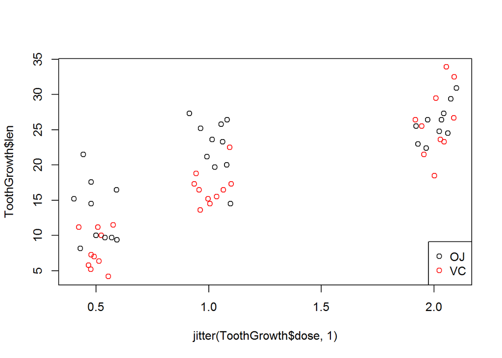

```r
data("ToothGrowth")

plot(ToothGrowth$len~jitter(ToothGrowth$dose,1), col=ToothGrowth$supp)
legend(x="bottomright", levels(ToothGrowth$supp), pch=1, col=c(1,2))
```

Plot을 눈으로 보았을때, `dose`가 증가함에 따라 `len`이 증가하는 경향이 있으며, `dose`가 0.5와 1.0일때는 `supp`가 ’VC’보다 ’OJ’일때가 `len`이 더 높음을 알 수 있다.

#### Linear model 만들기

```r
table(ToothGrowth$supp, ToothGrowth$dose)
```

```
##
##      0.5  1  2
##   OJ  10 10 10
##   VC  10 10 10
```

위 의 결과를 보면, `supp`와 `dose`사이에는 아무런 관계가 없이 균등히 분포함을 알 수 있다. 따라서 `supp`와 `dose`간의 interaction을 고려하지 않은 모델을 만든다.

```r
mdl <- lm(len~., data=ToothGrowth)
summary(mdl)
```

```
##
## Call:
## lm(formula = len ~ ., data = ToothGrowth)
##
## Residuals:
##    Min     1Q Median     3Q    Max
## -6.600 -3.700  0.373  2.116  8.800
##
## Coefficients:
##             Estimate Std. Error t value Pr(>|t|)
## (Intercept)   9.2725     1.2824   7.231 1.31e-09 ***
## suppVC       -3.7000     1.0936  -3.383   0.0013 **
## dose          9.7636     0.8768  11.135 6.31e-16 ***
## ---
## Signif. codes:  0 '***' 0.001 '**' 0.01 '*' 0.05 '.' 0.1 ' ' 1
##
## Residual standard error: 4.236 on 57 degrees of freedom
## Multiple R-squared:  0.7038, Adjusted R-squared:  0.6934
## F-statistic: 67.72 on 2 and 57 DF,  p-value: 8.716e-16
```

```r
anova(mdl)
```

```
## Analysis of Variance Table
##
## Response: len
##           Df  Sum Sq Mean Sq F value    Pr(>F)
## supp       1  205.35  205.35  11.447  0.001301 **
## dose       1 2224.30 2224.30 123.989 6.314e-16 ***
## Residuals 57 1022.56   17.94
## ---
## Signif. codes:  0 '***' 0.001 '**' 0.01 '*' 0.05 '.' 0.1 ' ' 1
```

F값과 t-test의 p값이 모두 유의하므로 최종모델로 정한다.

#### Fitted regression line 그리기

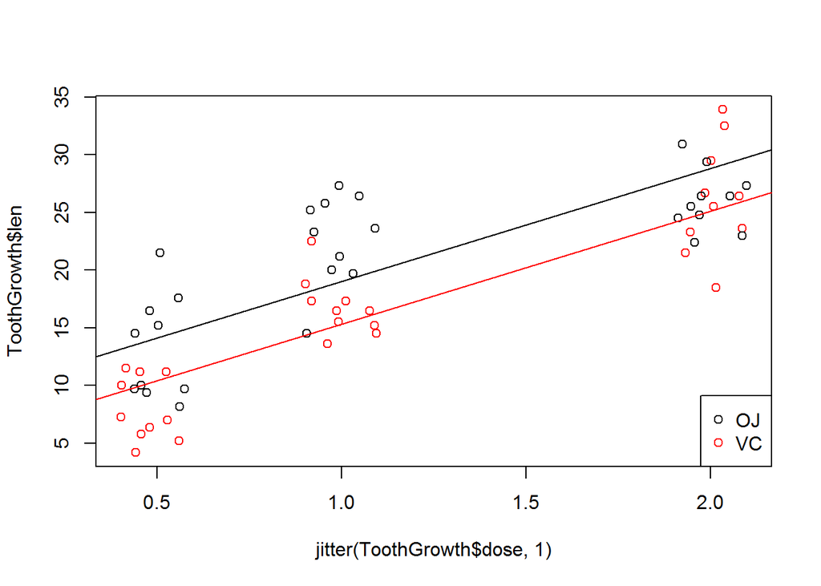

```r
plot(ToothGrowth$len~jitter(ToothGrowth$dose,1), col=ToothGrowth$supp)
legend(x="bottomright", levels(ToothGrowth$supp), pch=1, col=c(1,2))

abline(a=summary(mdl)$coeff[1,1], b= summary(mdl)$coeff[3,1], col=1)
abline(a=summary(mdl)$coeff[1,1]+summary(mdl)$coeff[2,1], b= summary(mdl)$coeff[3,1], col=2)
```

### 3. Find a good model for the uswages data with wages as the response and all the other variables as predictors.

```r
data(uswages)
summary(uswages)
```

```
##       wage              educ           exper            race
##  Min.   :  50.39   Min.   : 0.00   Min.   :-2.00   Min.   :0.000
##  1st Qu.: 308.64   1st Qu.:12.00   1st Qu.: 8.00   1st Qu.:0.000
##  Median : 522.32   Median :12.00   Median :15.00   Median :0.000
##  Mean   : 608.12   Mean   :13.11   Mean   :18.41   Mean   :0.078
##  3rd Qu.: 783.48   3rd Qu.:16.00   3rd Qu.:27.00   3rd Qu.:0.000
##  Max.   :7716.05   Max.   :18.00   Max.   :59.00   Max.   :1.000
##       smsa             ne              mw               so
##  Min.   :0.000   Min.   :0.000   Min.   :0.0000   Min.   :0.0000
##  1st Qu.:1.000   1st Qu.:0.000   1st Qu.:0.0000   1st Qu.:0.0000
##  Median :1.000   Median :0.000   Median :0.0000   Median :0.0000
##  Mean   :0.756   Mean   :0.229   Mean   :0.2485   Mean   :0.3125
##  3rd Qu.:1.000   3rd Qu.:0.000   3rd Qu.:0.0000   3rd Qu.:1.0000
##  Max.   :1.000   Max.   :1.000   Max.   :1.0000   Max.   :1.0000
##        we             pt
##  Min.   :0.00   Min.   :0.0000
##  1st Qu.:0.00   1st Qu.:0.0000
##  Median :0.00   Median :0.0000
##  Mean   :0.21   Mean   :0.0925
##  3rd Qu.:0.00   3rd Qu.:0.0000
##  Max.   :1.00   Max.   :1.0000
```

```r
uswages$race <- factor(uswages$race, labels=c("white","black"))
uswages$pt <- factor(uswages$pt, labels=c("Full-time", "Part-time"))
uswages$smsa <- factor(uswages$smsa, labels=c("Non-metropolitan","Metropolitan"))
```

사는 지역에 대한 변수 `ne`,`mw`,`we`,`so`를 하나로 묶는 새로운 변수를 만든다.

```r
loc <- numeric(2000)
loc[which(uswages$ne==1)] <- 1
loc[which(uswages$mw==1)] <- 2
loc[which(uswages$we==1)] <- 3
loc[which(uswages$so==1)] <- 4

loc <- factor(loc, labels=c("ne", "mw", "we", "so"))

wages <- data.frame(uswages[,c(1:5,10)],loc)

summary(wages)
```

```
##       wage              educ           exper          race
##  Min.   :  50.39   Min.   : 0.00   Min.   :-2.00   white:1844
##  1st Qu.: 308.64   1st Qu.:12.00   1st Qu.: 8.00   black: 156
##  Median : 522.32   Median :12.00   Median :15.00
##  Mean   : 608.12   Mean   :13.11   Mean   :18.41
##  3rd Qu.: 783.48   3rd Qu.:16.00   3rd Qu.:27.00
##  Max.   :7716.05   Max.   :18.00   Max.   :59.00
##                smsa              pt       loc
##  Non-metropolitan: 488   Full-time:1815   ne:458
##  Metropolitan    :1512   Part-time: 185   mw:497
##                                           we:420
##                                           so:625
##
##
```

`exper`변수는 재직연수를 나타낸다. 그러나 음수인 값이 있다.

```r
length(which(wages$exper < 0))
```

```
## [1] 33
```

`exper`값이 음수인 row는 33개이며, 이 row는 분석에서 제외한다.

```r
wages <- wages[-which(wages$exper < 0),]
```

#### 데이터 분석

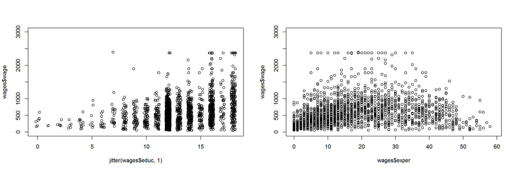

```r
par(mfrow=c(1,2))
plot(wages$wage~jitter(wages$educ,1), ylim=c(0,3000))
plot(wages$wage~wages$exper, ylim=c(0,3000))
```

```r
par(mfrow=c(1,1))
```

위의 두 plot을 보면, `wage`는 `educ`와 `exper`와 양의 상관관계를 갖는다. 또한 거의 대부분의 `wage`값은 2500보다 작다.

```r
length(which(wages$wage>2500))
```

```
## [1] 4
```

위에서 보듯이 `wage`가 2500을 넘는 경우는 4 건 뿐이다.

```r
mean(wages$wage[which(wages$wage>2500)])
```

```
## [1] 5102.225
```

이런 outlier들은 건수가 작음에도 불구하고 전체 `wage`의 평균에서 너무 많이 떨어져 있다. 따라서 `wage`에 대한 다른 변수들의 영향을 모델로 만드는데 영향을 줄 수 있으므로 `wage`가 2500을 넘는 4건을 제외한다.

```r
wages <- wages[-which(wages$wage>2500),]
```

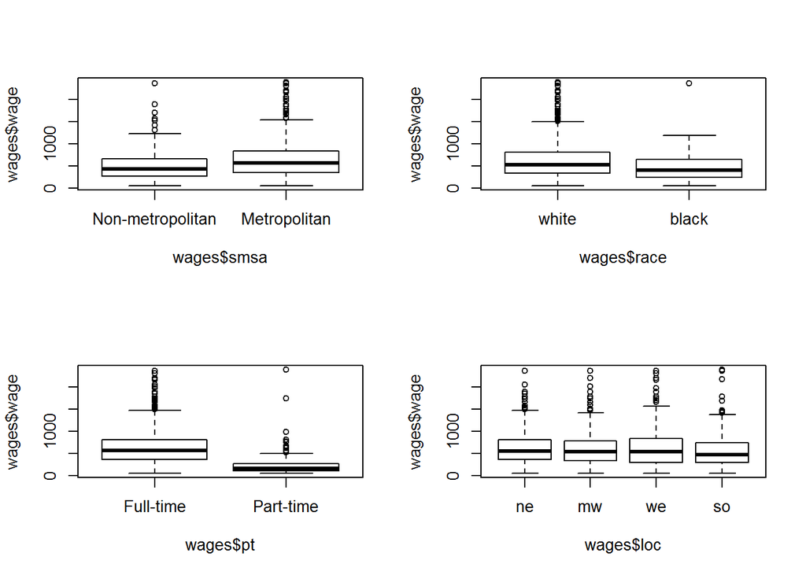

```r
par(mfrow=c(2,2))
plot(wages$wage~wages$smsa)
plot(wages$wage~wages$race)
plot(wages$wage~wages$pt)
plot(wages$wage~wages$loc)
```

```r
par(mfrow=c(1,1))
```

`pt`를 보면 풀타임으로 일하는 것이 `wage`가 월등히 높게 차이난다. `smsa`와 `race`에서는 ’Metropolitan’과 ’white’인 경우가 더 높은 `wage`를 가지는 경향이 있다. `loc`에 따라서는 `wage`의 큰 차이가 없어 보인다.

#### Linear model 만들기

우선 모든 변수를 predictor로 하여 모델을 만든다.

```r
mdl <- lm(wage~., data=wages)
summary(mdl)
```

```
##
## Call:
## lm(formula = wage ~ ., data = wages)
##
## Residuals:
##     Min      1Q  Median      3Q     Max
## -884.92 -205.25  -43.95  143.27 2471.76
##
## Coefficients:
##                  Estimate Std. Error t value Pr(>|t|)
## (Intercept)      -355.061     45.863  -7.742 1.56e-14 ***
## educ               57.503      2.716  21.174  < 2e-16 ***
## exper               8.689      0.610  14.244  < 2e-16 ***
## raceblack         -98.298     29.213  -3.365 0.000781 ***
## smsaMetropolitan   98.103     18.097   5.421 6.67e-08 ***
## ptPart-time      -390.528     27.941 -13.977  < 2e-16 ***
## locmw               4.162     22.482   0.185 0.853146
## locwe              43.557     23.371   1.864 0.062508 .
## locso               1.665     21.567   0.077 0.938462
## ---
## Signif. codes:  0 '***' 0.001 '**' 0.01 '*' 0.05 '.' 0.1 ' ' 1
##
## Residual standard error: 340.8 on 1954 degrees of freedom
## Multiple R-squared:  0.295,  Adjusted R-squared:  0.2922
## F-statistic: 102.2 on 8 and 1954 DF,  p-value: < 2.2e-16
```

```r
anova(mdl)
```

```
## Analysis of Variance Table
##
## Response: wage
##             Df    Sum Sq  Mean Sq  F value    Pr(>F)
## educ         1  40129355 40129355 345.5257 < 2.2e-16 ***
## exper        1  25991597 25991597 223.7954 < 2.2e-16 ***
## race         1   1664708  1664708  14.3336 0.0001577 ***
## smsa         1   3933960  3933960  33.8726 6.861e-09 ***
## pt           1  22699008 22699008 195.4452 < 2.2e-16 ***
## loc          3    562284   187428   1.6138 0.1841543
## Residuals 1954 226937592   116140
## ---
## Signif. codes:  0 '***' 0.001 '**' 0.01 '*' 0.05 '.' 0.1 ' ' 1
```

`loc`만이 F값과 t-test 모두 유의하지 않다. `loc`를 제외한다.

```r
mdl_i1 <- lm(wage~.-loc, data=wages)
summary(mdl_i1)
```

```
##
## Call:
## lm(formula = wage ~ . - loc, data = wages)
##
## Residuals:
##     Min      1Q  Median      3Q     Max
## -894.95 -202.70  -43.84  140.99 2461.68
##
## Coefficients:
##                   Estimate Std. Error t value Pr(>|t|)
## (Intercept)      -341.6393    42.3997  -8.058 1.34e-15 ***
## educ               57.4247     2.7136  21.161  < 2e-16 ***
## exper               8.6345     0.6094  14.170  < 2e-16 ***
## raceblack        -104.1153    28.7189  -3.625 0.000296 ***
## smsaMetropolitan   97.8259    17.9634   5.446 5.81e-08 ***
## ptPart-time      -390.3475    27.9346 -13.974  < 2e-16 ***
## ---
## Signif. codes:  0 '***' 0.001 '**' 0.01 '*' 0.05 '.' 0.1 ' ' 1
##
## Residual standard error: 341 on 1957 degrees of freedom
## Multiple R-squared:  0.2933, Adjusted R-squared:  0.2915
## F-statistic: 162.4 on 5 and 1957 DF,  p-value: < 2.2e-16
```

```r
anova(mdl_i1)
```

```
## Analysis of Variance Table
##
## Response: wage
##             Df    Sum Sq  Mean Sq F value    Pr(>F)
## educ         1  40129355 40129355 345.201 < 2.2e-16 ***
## exper        1  25991597 25991597 223.585 < 2.2e-16 ***
## race         1   1664708  1664708  14.320 0.0001588 ***
## smsa         1   3933960  3933960  33.841 6.971e-09 ***
## pt           1  22699008 22699008 195.262 < 2.2e-16 ***
## Residuals 1957 227499876   116249
## ---
## Signif. codes:  0 '***' 0.001 '**' 0.01 '*' 0.05 '.' 0.1 ' ' 1
```

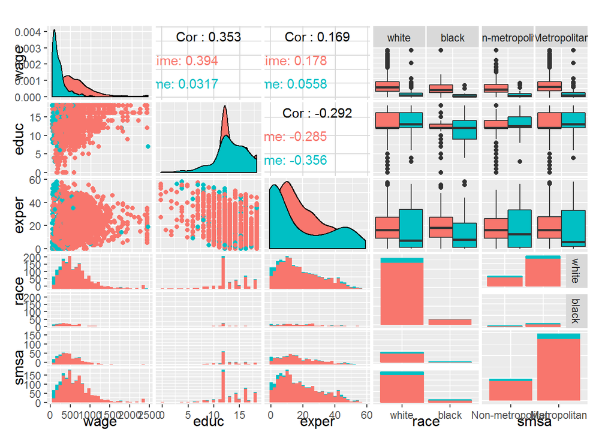

```r
library(ggplot2)
library(GGally)

ggpairs(wages[1:6], aes(color=pt), columns=c("wage", "educ","exper","race","smsa"))
```

붉은 색이 `pt`가 ‘Full time’, 푸른색이 ’Part time’이다. 남은 변수들 사이의 관계를 보면, - plot의 2행 3열에서 보듯이 `educ`와 `exper`사이에는 약한 음의 상관관계가 있다.(cor=-0.292) - plot의 대각선 방향으로 보면 `pt`에 따라서 `educ`와 `exper`의 분포에는 차이가 있지만, 나머지 변수들은 큰 차이가 없어 보인다.

```r
mdl_i2 <- lm(wage~(educ+exper+race+smsa)*pt, data=wages)
summary(mdl_i2)
```

```
##
## Call:
## lm(formula = wage ~ (educ + exper + race + smsa) * pt, data = wages)
##
## Residuals:
##     Min      1Q  Median      3Q     Max
## -937.32 -190.74  -42.75  134.50 2155.56
##
## Coefficients:
##                               Estimate Std. Error t value Pr(>|t|)
## (Intercept)                  -428.5423    43.8229  -9.779  < 2e-16 ***
## educ                           62.3891     2.7997  22.284  < 2e-16 ***
## exper                           9.8272     0.6583  14.929  < 2e-16 ***
## raceblack                    -112.8300    30.0205  -3.758 0.000176 ***
## smsaMetropolitan               97.9848    18.6302   5.259 1.60e-07 ***
## ptPart-time                   558.6221   150.6102   3.709 0.000214 ***
## educ:ptPart-time              -58.8467     9.8176  -5.994 2.43e-09 ***
## exper:ptPart-time              -8.7060     1.6574  -5.253 1.66e-07 ***
## raceblack:ptPart-time          42.0214    92.6551   0.454 0.650221
## smsaMetropolitan:ptPart-time  -36.1741    62.0120  -0.583 0.559732
## ---
## Signif. codes:  0 '***' 0.001 '**' 0.01 '*' 0.05 '.' 0.1 ' ' 1
##
## Residual standard error: 337.1 on 1953 degrees of freedom
## Multiple R-squared:  0.3108, Adjusted R-squared:  0.3076
## F-statistic: 97.85 on 9 and 1953 DF,  p-value: < 2.2e-16
```

```r
anova(mdl_i2)
```

```
## Analysis of Variance Table
##
## Response: wage
##             Df    Sum Sq  Mean Sq  F value    Pr(>F)
## educ         1  40129355 40129355 353.2378 < 2.2e-16 ***
## exper        1  25991597 25991597 228.7905 < 2.2e-16 ***
## race         1   1664708  1664708  14.6536 0.0001333 ***
## smsa         1   3933960  3933960  34.6286 4.684e-09 ***
## pt           1  22699008 22699008 199.8075 < 2.2e-16 ***
## educ:pt      1   2436371  2436371  21.4461 3.879e-06 ***
## exper:pt     1   3136844  3136844  27.6120 1.644e-07 ***
## race:pt      1     18696    18696   0.1646 0.6850270
## smsa:pt      1     38658    38658   0.3403 0.5597318
## Residuals 1953 221869307   113604
## ---
## Signif. codes:  0 '***' 0.001 '**' 0.01 '*' 0.05 '.' 0.1 ' ' 1
```

`pt`와 다른 변수들 간의 interaction을 고려한 모델을 만들어보면, 위의 plot에서 추정하였듯이 `pt:educ`와 `pt:exper`는 유의한 F값을 가지나 `race`, `smsa`와의 interaction은 유의하지 않다. t값도 마찬가지이다. 따라서 `pt:educ`와 `pt:exper`만을 모델에 포함시킨다.

```r
mdl_i3 <- lm(wage~.-loc+educ:pt+exper:pt, data=wages)
summary(mdl_i3)
```

```
##
## Call:
## lm(formula = wage ~ . - loc + educ:pt + exper:pt, data = wages)
##
## Residuals:
##     Min      1Q  Median      3Q     Max
## -939.88 -193.62  -42.89  135.70 2136.99
##
## Coefficients:
##                   Estimate Std. Error t value Pr(>|t|)
## (Intercept)       -427.565     43.665  -9.792  < 2e-16 ***
## educ                62.467      2.796  22.338  < 2e-16 ***
## exper                9.832      0.658  14.944  < 2e-16 ***
## raceblack         -108.652     28.387  -3.828 0.000134 ***
## smsaMetropolitan    94.804     17.762   5.338 1.05e-07 ***
## ptPart-time        548.846    143.172   3.833 0.000130 ***
## educ:ptPart-time   -59.772      9.697  -6.164 8.58e-10 ***
## exper:ptPart-time   -8.695      1.654  -5.257 1.63e-07 ***
## ---
## Signif. codes:  0 '***' 0.001 '**' 0.01 '*' 0.05 '.' 0.1 ' ' 1
##
## Residual standard error: 336.9 on 1955 degrees of freedom
## Multiple R-squared:  0.3106, Adjusted R-squared:  0.3081
## F-statistic: 125.8 on 7 and 1955 DF,  p-value: < 2.2e-16
```

```r
anova(mdl_i3)
```

```
## Analysis of Variance Table
##
## Response: wage
##             Df    Sum Sq  Mean Sq F value    Pr(>F)
## educ         1  40129355 40129355 353.508 < 2.2e-16 ***
## exper        1  25991597 25991597 228.966 < 2.2e-16 ***
## race         1   1664708  1664708  14.665 0.0001325 ***
## smsa         1   3933960  3933960  34.655 4.621e-09 ***
## pt           1  22699008 22699008 199.960 < 2.2e-16 ***
## educ:pt      1   2436371  2436371  21.462 3.846e-06 ***
## exper:pt     1   3136844  3136844  27.633 1.627e-07 ***
## Residuals 1955 221926661   113517
## ---
## Signif. codes:  0 '***' 0.001 '**' 0.01 '*' 0.05 '.' 0.1 ' ' 1
```

남은 `race`와 `smsa`와 남은 변수들의 interaction도 확인한다. `race`와 남은 변수들간의 interaction 추가

```r
mdl_i4 <- lm(wage~.-loc+educ:pt+exper:pt+educ:race+exper:race+smsa:race, data=wages)
summary(mdl_i4)
```

```
##
## Call:
## lm(formula = wage ~ . - loc + educ:pt + exper:pt + educ:race +
##     exper:race + smsa:race, data = wages)
##
## Residuals:
##     Min      1Q  Median      3Q     Max
## -943.53 -193.71  -46.03  137.58 2153.52
##
## Coefficients:
##                             Estimate Std. Error t value Pr(>|t|)
## (Intercept)                -447.5005    44.5748 -10.039  < 2e-16 ***
## educ                         63.4328     2.8553  22.216  < 2e-16 ***
## exper                         9.9953     0.6769  14.765  < 2e-16 ***
## raceblack                   246.4919   168.2845   1.465 0.143155
## smsaMetropolitan            100.4210    18.3576   5.470 5.07e-08 ***
## ptPart-time                 517.8193   144.1954   3.591 0.000337 ***
## educ:ptPart-time            -57.8471     9.7611  -5.926 3.65e-09 ***
## exper:ptPart-time            -8.4065     1.6589  -5.068 4.41e-07 ***
## educ:raceblack              -19.5948    11.5711  -1.693 0.090535 .
## exper:raceblack              -2.9249     2.2943  -1.275 0.202504
## raceblack:smsaMetropolitan  -72.5394    73.0550  -0.993 0.320861
## ---
## Signif. codes:  0 '***' 0.001 '**' 0.01 '*' 0.05 '.' 0.1 ' ' 1
##
## Residual standard error: 336.7 on 1952 degrees of freedom
## Multiple R-squared:  0.3124, Adjusted R-squared:  0.3089
## F-statistic: 88.68 on 10 and 1952 DF,  p-value: < 2.2e-16
```

```r
anova(mdl_i4)
```

```
## Analysis of Variance Table
##
## Response: wage
##              Df    Sum Sq  Mean Sq  F value    Pr(>F)
## educ          1  40129355 40129355 353.8729 < 2.2e-16 ***
## exper         1  25991597 25991597 229.2018 < 2.2e-16 ***
## race          1   1664708  1664708  14.6799 0.0001314 ***
## smsa          1   3933960  3933960  34.6909 4.540e-09 ***
## pt            1  22699008 22699008 200.1668 < 2.2e-16 ***
## educ:pt       1   2436371  2436371  21.4847 3.803e-06 ***
## exper:pt      1   3136844  3136844  27.6616 1.603e-07 ***
## educ:race     1    218994   218994   1.9312 0.1647905
## exper:race    1    238128   238128   2.0999 0.1474711
## race:smsa     1    111805   111805   0.9859 0.3208613
## Residuals  1952 221357734   113400
## ---
## Signif. codes:  0 '***' 0.001 '**' 0.01 '*' 0.05 '.' 0.1 ' ' 1
```

`race:smsa` 제외

```r
mdl_i4_2 <- lm(wage~.-loc+educ:pt+exper:pt+educ:race+exper:race, data=wages)
summary(mdl_i4_2)
```

```
##
## Call:
## lm(formula = wage ~ . - loc + educ:pt + exper:pt + educ:race +
##     exper:race, data = wages)
##
## Residuals:
##     Min      1Q  Median      3Q     Max
## -947.42 -192.51  -45.24  137.89 2157.14
##
## Coefficients:
##                    Estimate Std. Error t value Pr(>|t|)
## (Intercept)       -444.7753    44.4901  -9.997  < 2e-16 ***
## educ                63.4738     2.8550  22.233  < 2e-16 ***
## exper               10.0065     0.6768  14.784  < 2e-16 ***
## raceblack          216.0066   165.4595   1.305 0.191878
## smsaMetropolitan    95.8215    17.7635   5.394 7.71e-08 ***
## ptPart-time        514.2318   144.1496   3.567 0.000369 ***
## educ:ptPart-time   -57.5618     9.7568  -5.900 4.28e-09 ***
## exper:ptPart-time   -8.4410     1.6585  -5.090 3.93e-07 ***
## educ:raceblack     -21.3268    11.4389  -1.864 0.062413 .
## exper:raceblack     -3.2832     2.2657  -1.449 0.147470
## ---
## Signif. codes:  0 '***' 0.001 '**' 0.01 '*' 0.05 '.' 0.1 ' ' 1
##
## Residual standard error: 336.7 on 1953 degrees of freedom
## Multiple R-squared:  0.312,  Adjusted R-squared:  0.3089
## F-statistic: 98.42 on 9 and 1953 DF,  p-value: < 2.2e-16
```

```r
anova(mdl_i4_2)
```

```
## Analysis of Variance Table
##
## Response: wage
##              Df    Sum Sq  Mean Sq  F value    Pr(>F)
## educ          1  40129355 40129355 353.8754 < 2.2e-16 ***
## exper         1  25991597 25991597 229.2035 < 2.2e-16 ***
## race          1   1664708  1664708  14.6800 0.0001314 ***
## smsa          1   3933960  3933960  34.6911 4.539e-09 ***
## pt            1  22699008 22699008 200.1682 < 2.2e-16 ***
## educ:pt       1   2436371  2436371  21.4848 3.802e-06 ***
## exper:pt      1   3136844  3136844  27.6618 1.603e-07 ***
## educ:race     1    218994   218994   1.9312 0.1647889
## exper:race    1    238128   238128   2.0999 0.1474695
## Residuals  1953 221469540   113400
## ---
## Signif. codes:  0 '***' 0.001 '**' 0.01 '*' 0.05 '.' 0.1 ' ' 1
```

`race:exper`제외

```r
mdl_i4_3 <- lm(wage~.-loc+educ:pt+exper:pt+educ:race, data=wages)
summary(mdl_i4_3)
```

```
##
## Call:
## lm(formula = wage ~ . - loc + educ:pt + exper:pt + educ:race,
##     data = wages)
##
## Residuals:
##     Min      1Q  Median      3Q     Max
## -942.57 -193.59  -43.84  136.07 2150.06
##
## Coefficients:
##                    Estimate Std. Error t value Pr(>|t|)
## (Intercept)       -436.9357    44.1723  -9.892  < 2e-16 ***
## educ                63.2457     2.8514  22.180  < 2e-16 ***
## exper                9.7807     0.6588  14.845  < 2e-16 ***
## raceblack           67.5409   129.9601   0.520 0.603328
## smsaMetropolitan    94.9184    17.7576   5.345 1.01e-07 ***
## ptPart-time        530.0105   143.7782   3.686 0.000234 ***
## educ:ptPart-time   -58.4795     9.7390  -6.005 2.28e-09 ***
## exper:ptPart-time   -8.6157     1.6546  -5.207 2.12e-07 ***
## educ:raceblack     -14.4742    10.4186  -1.389 0.164908
## ---
## Signif. codes:  0 '***' 0.001 '**' 0.01 '*' 0.05 '.' 0.1 ' ' 1
##
## Residual standard error: 336.8 on 1954 degrees of freedom
## Multiple R-squared:  0.3113, Adjusted R-squared:  0.3085
## F-statistic: 110.4 on 8 and 1954 DF,  p-value: < 2.2e-16
```

```r
anova(mdl_i4_3)
```

```
## Analysis of Variance Table
##
## Response: wage
##             Df    Sum Sq  Mean Sq  F value    Pr(>F)
## educ         1  40129355 40129355 353.6764 < 2.2e-16 ***
## exper        1  25991597 25991597 229.0745 < 2.2e-16 ***
## race         1   1664708  1664708  14.6717  0.000132 ***
## smsa         1   3933960  3933960  34.6716 4.583e-09 ***
## pt           1  22699008 22699008 200.0556 < 2.2e-16 ***
## educ:pt      1   2436371  2436371  21.4727 3.826e-06 ***
## exper:pt     1   3136844  3136844  27.6463 1.616e-07 ***
## educ:race    1    218994   218994   1.9301  0.164908
## Residuals 1954 221707667   113463
## ---
## Signif. codes:  0 '***' 0.001 '**' 0.01 '*' 0.05 '.' 0.1 ' ' 1
```

`race:educ`제외

```r
mdl_i4_4 <- lm(wage~.-loc+educ:pt+exper:pt, data=wages)
summary(mdl_i4_4)
```

```
##
## Call:
## lm(formula = wage ~ . - loc + educ:pt + exper:pt, data = wages)
##
## Residuals:
##     Min      1Q  Median      3Q     Max
## -939.88 -193.62  -42.89  135.70 2136.99
##
## Coefficients:
##                   Estimate Std. Error t value Pr(>|t|)
## (Intercept)       -427.565     43.665  -9.792  < 2e-16 ***
## educ                62.467      2.796  22.338  < 2e-16 ***
## exper                9.832      0.658  14.944  < 2e-16 ***
## raceblack         -108.652     28.387  -3.828 0.000134 ***
## smsaMetropolitan    94.804     17.762   5.338 1.05e-07 ***
## ptPart-time        548.846    143.172   3.833 0.000130 ***
## educ:ptPart-time   -59.772      9.697  -6.164 8.58e-10 ***
## exper:ptPart-time   -8.695      1.654  -5.257 1.63e-07 ***
## ---
## Signif. codes:  0 '***' 0.001 '**' 0.01 '*' 0.05 '.' 0.1 ' ' 1
##
## Residual standard error: 336.9 on 1955 degrees of freedom
## Multiple R-squared:  0.3106, Adjusted R-squared:  0.3081
## F-statistic: 125.8 on 7 and 1955 DF,  p-value: < 2.2e-16
```

```r
anova(mdl_i4_4)
```

```
## Analysis of Variance Table
##
## Response: wage
##             Df    Sum Sq  Mean Sq F value    Pr(>F)
## educ         1  40129355 40129355 353.508 < 2.2e-16 ***
## exper        1  25991597 25991597 228.966 < 2.2e-16 ***
## race         1   1664708  1664708  14.665 0.0001325 ***
## smsa         1   3933960  3933960  34.655 4.621e-09 ***
## pt           1  22699008 22699008 199.960 < 2.2e-16 ***
## educ:pt      1   2436371  2436371  21.462 3.846e-06 ***
## exper:pt     1   3136844  3136844  27.633 1.627e-07 ***
## Residuals 1955 221926661   113517
## ---
## Signif. codes:  0 '***' 0.001 '**' 0.01 '*' 0.05 '.' 0.1 ' ' 1
```

`smsa`와 남은 변수간의 interaction 추가

```r
mdl_i5 <- lm(wage~.-loc+educ:pt+exper:pt+educ:smsa+exper:smsa, data=wages)
summary(mdl_i5)
```

```
##
## Call:
## lm(formula = wage ~ . - loc + educ:pt + exper:pt + educ:smsa +
##     exper:smsa, data = wages)
##
## Residuals:
##     Min      1Q  Median      3Q     Max
## -949.17 -191.28  -44.33  134.82 2140.95
##
## Coefficients:
##                        Estimate Std. Error t value Pr(>|t|)
## (Intercept)            -253.197     83.990  -3.015  0.00261 **
## educ                     52.781      5.831   9.051  < 2e-16 ***
## exper                     7.018      1.281   5.478 4.85e-08 ***
## raceblack              -110.889     28.353  -3.911 9.51e-05 ***
## smsaMetropolitan       -136.317     95.512  -1.427  0.15368
## ptPart-time             576.902    143.258   4.027 5.87e-05 ***
## educ:ptPart-time        -61.665      9.704  -6.355 2.59e-10 ***
## exper:ptPart-time        -8.695      1.657  -5.248 1.70e-07 ***
## educ:smsaMetropolitan    12.720      6.531   1.948  0.05159 .
## exper:smsaMetropolitan    3.696      1.423   2.598  0.00946 **
## ---
## Signif. codes:  0 '***' 0.001 '**' 0.01 '*' 0.05 '.' 0.1 ' ' 1
##
## Residual standard error: 336.4 on 1953 degrees of freedom
## Multiple R-squared:  0.3136, Adjusted R-squared:  0.3104
## F-statistic: 99.14 on 9 and 1953 DF,  p-value: < 2.2e-16
```

```r
anova(mdl_i5)
```

```
## Analysis of Variance Table
##
## Response: wage
##              Df    Sum Sq  Mean Sq  F value    Pr(>F)
## educ          1  40129355 40129355 354.6841 < 2.2e-16 ***
## exper         1  25991597 25991597 229.7272 < 2.2e-16 ***
## race          1   1664708  1664708  14.7136 0.0001291 ***
## smsa          1   3933960  3933960  34.7704 4.361e-09 ***
## pt            1  22699008 22699008 200.6256 < 2.2e-16 ***
## educ:pt       1   2436371  2436371  21.5339 3.707e-06 ***
## exper:pt      1   3136844  3136844  27.7251 1.552e-07 ***
## educ:smsa     1    198585   198585   1.7552 0.1853797
## exper:smsa    1    763466   763466   6.7479 0.0094563 **
## Residuals  1953 220964610   113141
## ---
## Signif. codes:  0 '***' 0.001 '**' 0.01 '*' 0.05 '.' 0.1 ' ' 1
```

`educ:smsa`은 유의한 F 값을 보이지 않는다. 그러므로 `exper:smsa`만을 추가한다.

```r
mdl_i6 <- lm(wage~.-loc+educ:pt+exper:pt+exper:smsa, data=wages)
summary(mdl_i6)
```

```
##
## Call:
## lm(formula = wage ~ . - loc + educ:pt + exper:pt + exper:smsa,
##     data = wages)
##
## Residuals:
##     Min      1Q  Median      3Q     Max
## -938.24 -192.36  -42.24  137.36 2127.97
##
## Coefficients:
##                        Estimate Std. Error t value Pr(>|t|)
## (Intercept)            -388.575     47.183  -8.235 3.23e-16 ***
## educ                     62.749      2.797  22.436  < 2e-16 ***
## exper                     7.509      1.257   5.975 2.72e-09 ***
## raceblack              -110.496     28.373  -3.894 0.000102 ***
## smsaMetropolitan         39.647     31.013   1.278 0.201257
## ptPart-time             564.902    143.228   3.944 8.29e-05 ***
## educ:ptPart-time        -61.078      9.706  -6.293 3.84e-10 ***
## exper:ptPart-time        -8.498      1.655  -5.135 3.10e-07 ***
## exper:smsaMetropolitan    2.984      1.376   2.169 0.030233 *
## ---
## Signif. codes:  0 '***' 0.001 '**' 0.01 '*' 0.05 '.' 0.1 ' ' 1
##
## Residual standard error: 336.6 on 1954 degrees of freedom
## Multiple R-squared:  0.3123, Adjusted R-squared:  0.3095
## F-statistic: 110.9 on 8 and 1954 DF,  p-value: < 2.2e-16
```

```r
anova(mdl_i6)
```

```
## Analysis of Variance Table
##
## Response: wage
##              Df    Sum Sq  Mean Sq  F value    Pr(>F)
## educ          1  40129355 40129355 354.1777 < 2.2e-16 ***
## exper         1  25991597 25991597 229.3993 < 2.2e-16 ***
## race          1   1664708  1664708  14.6925 0.0001305 ***
## smsa          1   3933960  3933960  34.7207 4.471e-09 ***
## pt            1  22699008 22699008 200.3392 < 2.2e-16 ***
## educ:pt       1   2436371  2436371  21.5032 3.766e-06 ***
## exper:pt      1   3136844  3136844  27.6855 1.584e-07 ***
## exper:smsa    1    532846   532846   4.7028 0.0302330 *
## Residuals  1954 221393815   113303
## ---
## Signif. codes:  0 '***' 0.001 '**' 0.01 '*' 0.05 '.' 0.1 ' ' 1
```

`smsa`의 t-test가 유의하지 않으므로 제외한다.

```r
mdl_i7 <- lm(wage~.-loc+educ:pt+exper:pt+exper:smsa-smsa,  data=wages)
summary(mdl_i7)
```

```
##
## Call:
## lm(formula = wage ~ . - loc + educ:pt + exper:pt + exper:smsa -
##     smsa, data = wages)
##
## Residuals:
##     Min      1Q  Median      3Q     Max
## -941.14 -189.63  -41.76  136.36 2128.14
##
## Coefficients:
##                         Estimate Std. Error t value Pr(>|t|)
## (Intercept)            -362.8331    42.6776  -8.502  < 2e-16 ***
## educ                     63.0711     2.7859  22.639  < 2e-16 ***
## exper                     6.4095     0.9163   6.995 3.62e-12 ***
## raceblack              -110.3816    28.3774  -3.890 0.000104 ***
## ptPart-time             573.7618   143.0832   4.010 6.30e-05 ***
## educ:ptPart-time        -61.7788     9.6923  -6.374 2.29e-10 ***
## exper:ptPart-time        -8.4449     1.6547  -5.104 3.65e-07 ***
## exper:smsaMetropolitan    4.4269     0.7875   5.622 2.16e-08 ***
## ---
## Signif. codes:  0 '***' 0.001 '**' 0.01 '*' 0.05 '.' 0.1 ' ' 1
##
## Residual standard error: 336.7 on 1955 degrees of freedom
## Multiple R-squared:  0.3117, Adjusted R-squared:  0.3092
## F-statistic: 126.5 on 7 and 1955 DF,  p-value: < 2.2e-16
```

```r
anova(mdl_i7)
```

```
## Analysis of Variance Table
##
## Response: wage
##              Df    Sum Sq  Mean Sq F value    Pr(>F)
## educ          1  40129355 40129355 354.063 < 2.2e-16 ***
## exper         1  25991597 25991597 229.325 < 2.2e-16 ***
## race          1   1664708  1664708  14.688 0.0001309 ***
## pt            1  23185344 23185344 204.565 < 2.2e-16 ***
## educ:pt       1   2423633  2423633  21.384 4.005e-06 ***
## exper:pt      1   3363113  3363113  29.673 5.760e-08 ***
## exper:smsa    1   3581764  3581764  31.602 2.164e-08 ***
## Residuals  1955 221578990   113340
## ---
## Signif. codes:  0 '***' 0.001 '**' 0.01 '*' 0.05 '.' 0.1 ' ' 1
```

최종모델

```r
summary(mdl_i7)
```

```
##
## Call:
## lm(formula = wage ~ . - loc + educ:pt + exper:pt + exper:smsa -
##     smsa, data = wages)
##
## Residuals:
##     Min      1Q  Median      3Q     Max
## -941.14 -189.63  -41.76  136.36 2128.14
##
## Coefficients:
##                         Estimate Std. Error t value Pr(>|t|)
## (Intercept)            -362.8331    42.6776  -8.502  < 2e-16 ***
## educ                     63.0711     2.7859  22.639  < 2e-16 ***
## exper                     6.4095     0.9163   6.995 3.62e-12 ***
## raceblack              -110.3816    28.3774  -3.890 0.000104 ***
## ptPart-time             573.7618   143.0832   4.010 6.30e-05 ***
## educ:ptPart-time        -61.7788     9.6923  -6.374 2.29e-10 ***
## exper:ptPart-time        -8.4449     1.6547  -5.104 3.65e-07 ***
## exper:smsaMetropolitan    4.4269     0.7875   5.622 2.16e-08 ***
## ---
## Signif. codes:  0 '***' 0.001 '**' 0.01 '*' 0.05 '.' 0.1 ' ' 1
##
## Residual standard error: 336.7 on 1955 degrees of freedom
## Multiple R-squared:  0.3117, Adjusted R-squared:  0.3092
## F-statistic: 126.5 on 7 and 1955 DF,  p-value: < 2.2e-16
```